# Vectors

Start by making a vector with the numbers 1 through 26.

Multiply the vector by 2.

Give the resulting vector names A through Z.

Hint: there is a built in vector called `LETTERS`

```r
x <- 1:26
x <- x * 2
names(x) <- LETTERS
x
```

```
##  A  B  C  D  E  F  G  H  I  J  K  L  M  N  O  P  Q  R  S  T  U  V  W  X  Y
##  2  4  6  8 10 12 14 16 18 20 22 24 26 28 30 32 34 36 38 40 42 44 46 48 50
##  Z
## 52
```

Set the 10th and 13th elements of the vector you made in the last exercise to missing.

```r
x[c(10, 13)]<-NA
x
```

```
##  A  B  C  D  E  F  G  H  I  J  K  L  M  N  O  P  Q  R  S  T  U  V  W  X  Y
##  2  4  6  8 10 12 14 16 18 NA 22 24 NA 28 30 32 34 36 38 40 42 44 46 48 50
##  Z
## 52
```

Select every other element, starting with the second, of the vector you’re working with. See the help for `seq` to help with this.

```r
x[seq(2, length(x), 2)]
```

```
##  B  D  F  H  J  L  N  P  R  T  V  X  Z
##  4  8 12 16 NA 24 28 32 36 40 44 48 52
```

# Data Frames

Make a data frame called `cats` that has this structure and values:

```
  coat weight likes_string
calico    2.1            1
 black    5.0            0
 tabby    3.2            1
```

```r
cats<-data.frame(coat=c("calico","black","tabby"),
                 weight=c(2.1, 5, 3.2),
                 likes_string=c(1,0,1))
```

Select the rows from your data frame where the cats’ weight is greater than 3.

```r
cats[cats$weight > 3,]
```

```
##    coat weight likes_string
## 2 black    5.0            0
## 3 tabby    3.2            1
```

What does each of the following do?

```
cats[1]
cats[[1]]
cats$coat
cats["coat"]
cats[1, 1]
cats[, 1]
cats[1,]
cats[-1,]
```

Hint: Use the function `typeof()` to examine what is returned in each case.

Add a column for `age` to `cats`. Fill it in with whatever values you want.

```r
cats$age<-c(3,5,7)
```

# Reading Data

Read in the data from https://goo.gl/IFCKAm to a data frame called `gapminder`. Do you need to make any adjustments to the defaults?

Look at the type of each column in the data you read in.

View the observations for Belgium.

```r
gapminder<-read.csv("https://goo.gl/IFCKAm")
str(gapminder)
View(gapminder[gapminder$country=="Belgium",])
```

# Loops and Conditionals

Use an if() statement to print a suitable message reporting whether there are any records from 2002 in the gapminder dataset. Now do the same for 2012.

Hint: use the `any` function

```r
if(any(gapminder$year == 2002)){
   print("Record(s) for the year 2002 found.")
}
```

or

```r
if(nrow(gapminder[(gapminder$year == 2002),]) >= 1){
   print("Record(s) for the year 2002 found.")
}
```

Write a script that loops through the `gapminder` data by continent and prints out whether the mean life expectancy is smaller or larger than 50 years.

```r
thresholdValue <- 50

for(iContinent in unique(gapminder$continent)) {
   tmp <- mean(subset(gapminder, continent==iContinent)$lifeExp)

   if(tmp < thresholdValue) {
       cat("Average Life Expectancy in", iContinent, "is less than", thresholdValue, "\n")
   } else {
       cat("Average Life Expectancy in", iContinent, "is greater than", thresholdValue, "\n")
   } # end if else condition

} # end for loop
```

```
## Average Life Expectancy in Asia is greater than 50
## Average Life Expectancy in Europe is greater than 50
## Average Life Expectancy in Africa is less than 50
## Average Life Expectancy in Americas is greater than 50
## Average Life Expectancy in Oceania is greater than 50
```

Modify the script from the last exercise to loop over each country. This time print out whether the life expectancy is smaller than 50, between 50 and 70, or greater than 70.

```r
lowerThreshold <- 50
upperThreshold <- 70

for(iCountry in unique(gapminder$country)){
    tmp <- mean(subset(gapminder, country==iCountry)$lifeExp)

    if(tmp < lowerThreshold){
        cat("Average Life Expectancy in", iCountry, "is less than", lowerThreshold, "\n")
    }
    else if(tmp > lowerThreshold && tmp < upperThreshold){
        cat("Average Life Expectancy in", iCountry, "is between", lowerThreshold, "and", upperThreshold, "\n")
    }
    else{
        cat("Average Life Expectancy in", iCountry, "is greater than", upperThreshold, "\n")
    }

}
```

```
## Average Life Expectancy in Afghanistan is less than 50
## Average Life Expectancy in Albania is between 50 and 70
## Average Life Expectancy in Algeria is between 50 and 70
## Average Life Expectancy in Angola is less than 50
## Average Life Expectancy in Argentina is between 50 and 70
## Average Life Expectancy in Australia is greater than 70
## Average Life Expectancy in Austria is greater than 70
## Average Life Expectancy in Bahrain is between 50 and 70
## Average Life Expectancy in Bangladesh is less than 50
## Average Life Expectancy in Belgium is greater than 70
## Average Life Expectancy in Benin is less than 50
## Average Life Expectancy in Bolivia is between 50 and 70
## Average Life Expectancy in Bosnia and Herzegovina is between 50 and 70
## Average Life Expectancy in Botswana is between 50 and 70
## Average Life Expectancy in Brazil is between 50 and 70
## Average Life Expectancy in Bulgaria is between 50 and 70
## Average Life Expectancy in Burkina Faso is less than 50
## Average Life Expectancy in Burundi is less than 50
## Average Life Expectancy in Cambodia is less than 50
## Average Life Expectancy in Cameroon is less than 50
## Average Life Expectancy in Canada is greater than 70
## Average Life Expectancy in Central African Republic is less than 50
## Average Life Expectancy in Chad is less than 50
## Average Life Expectancy in Chile is between 50 and 70
## Average Life Expectancy in China is between 50 and 70
## Average Life Expectancy in Colombia is between 50 and 70
## Average Life Expectancy in Comoros is between 50 and 70
## Average Life Expectancy in Congo Dem. Rep. is less than 50
## Average Life Expectancy in Congo Rep. is between 50 and 70
## Average Life Expectancy in Costa Rica is greater than 70
## Average Life Expectancy in Cote d'Ivoire is less than 50
## Average Life Expectancy in Croatia is greater than 70
## Average Life Expectancy in Cuba is greater than 70
## Average Life Expectancy in Czech Republic is greater than 70
## Average Life Expectancy in Denmark is greater than 70
## Average Life Expectancy in Djibouti is less than 50
## Average Life Expectancy in Dominican Republic is between 50 and 70
## Average Life Expectancy in Ecuador is between 50 and 70
## Average Life Expectancy in Egypt is between 50 and 70
## Average Life Expectancy in El Salvador is between 50 and 70
```

[output cut: 87 more lines]

```
## Average Life Expectancy in Thailand is between 50 and 70
## Average Life Expectancy in Togo is between 50 and 70
## Average Life Expectancy in Trinidad and Tobago is between 50 and 70
## Average Life Expectancy in Tunisia is between 50 and 70
## Average Life Expectancy in Turkey is between 50 and 70
## Average Life Expectancy in Uganda is less than 50
## Average Life Expectancy in United Kingdom is greater than 70
## Average Life Expectancy in United States is greater than 70
## Average Life Expectancy in Uruguay is greater than 70
## Average Life Expectancy in Venezuela is between 50 and 70
## Average Life Expectancy in Vietnam is between 50 and 70
## Average Life Expectancy in West Bank and Gaza is between 50 and 70
## Average Life Expectancy in Yemen Rep. is less than 50
## Average Life Expectancy in Zambia is less than 50
## Average Life Expectancy in Zimbabwe is between 50 and 70
```

# `dplyr`

Using the `gapminder` data, write a single command (which can span multiple lines and includes pipes) that will produce a dataframe that has the African values for lifeExp, country and year, but not for other Continents.

```r
gapminder %>%
  filter(continent=="Africa") %>%
  select(year,country,lifeExp)
```

Calculate the average life expectancy per country. Which has the longest average life expectancy and which has the shortest average life expectancy?

```r
lifeExp_bycountry <- gapminder %>%
   group_by(country) %>%
   summarize(mean_lifeExp=mean(lifeExp))

lifeExp_bycountry %>%
   filter(mean_lifeExp == min(mean_lifeExp) | mean_lifeExp == max(mean_lifeExp))

lifeExp_bycountry %>%
   arrange(mean_lifeExp) %>%
   head(1)

lifeExp_bycountry %>%
   arrange(desc(mean_lifeExp)) %>%
   head(1)
```

Calculate the average life expectancy in 2002 of 2 randomly selected countries for each continent. Then arrange the continent names in reverse order. Hint: Use the dplyr functions `arrange()` and `sample_n()`, they have similar syntax to other dplyr functions.

```r
lifeExp_2countries_bycontinents <- gapminder %>%
   filter(year==2002) %>%
   group_by(continent) %>%
   sample_n(2) %>%
   summarize(mean_lifeExp=mean(lifeExp)) %>%
   arrange(desc(mean_lifeExp))
```

# `ggplot2`

Using the `gapminder` data, plot life expectancy vs. year. Then color the points by continent.

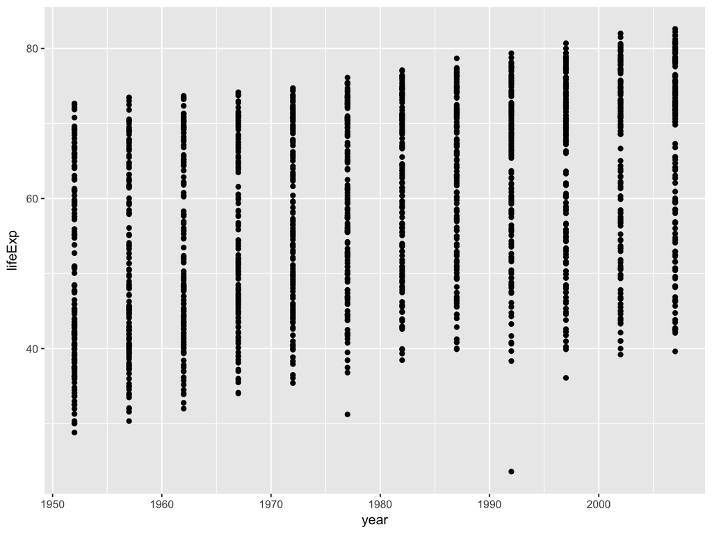

```r
ggplot(data = gapminder, aes(x = year, y = lifeExp)) + geom_point()
```

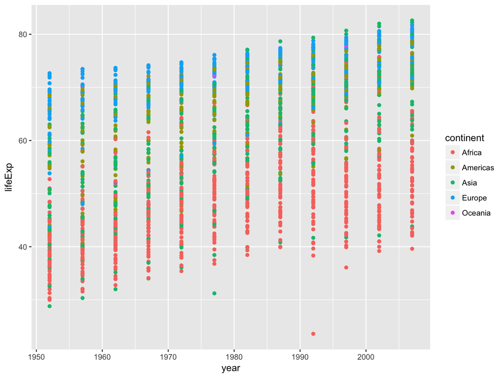

```r
ggplot(data = gapminder, aes(x = year, y = lifeExp, color=continent)) +
  geom_point()
```

Starting with

```r
ggplot(data = gapminder, aes(x = gdpPercap, y = lifeExp)) +
  geom_point() + scale_x_log10() + geom_smooth(method="lm", size=1.5)
```

1. Modify the color and size of the points on the point layer.
2. Modify your solution so that the points are now a different shape and are colored by continent with new trendlines.

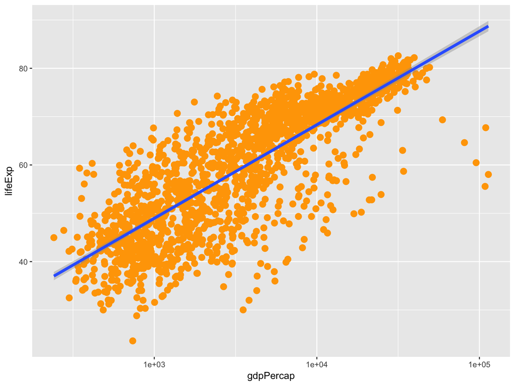

```r
ggplot(data = gapminder, aes(x = gdpPercap, y = lifeExp)) +
 geom_point(size=3, color="orange") + scale_x_log10() +
 geom_smooth(method="lm", size=1.5)
```

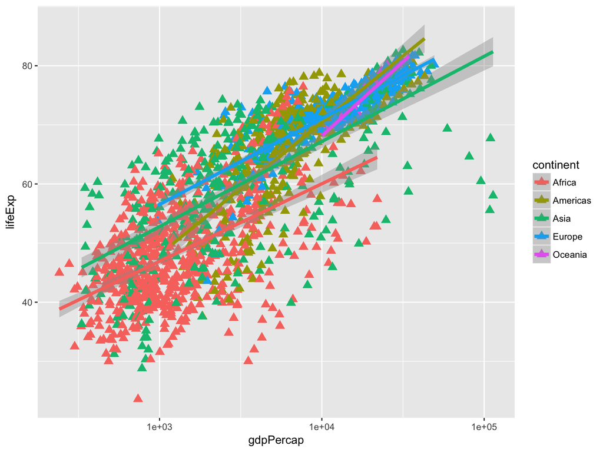

```r
ggplot(data = gapminder, aes(x = gdpPercap, y = lifeExp, color = continent)) +
  geom_point(size=3, shape=17) + scale_x_log10() +
  geom_smooth(method="lm", size=1.5)
```

# Data Manipulation

Add a new column to `gapminder` that is the population in millions.

Make a new data frame, `gapminder2007` that just contains the observations for 2007.

```r
gapminder$popmillion <- gapminder$pop/1000000
gapminder2007 <- gapminder[gapminder$year==2007,]
```

Do a t-test using `gapminder2007` to see if life expectancy is different in Europe and Asia.

```r
t.test(gapminder2007$lifeExp[gapminder2007$continent=="Europe"],
       gapminder2007$lifeExp[gapminder2007$continent=="Asia"])
```

```
##
##  Welch Two Sample t-test
##
## data:  gapminder2007$lifeExp[gapminder2007$continent == "Europe"] and gapminder2007$lifeExp[gapminder2007$continent == "Asia"]
## t = 4.6468, df = 41.529, p-value = 3.389e-05
## alternative hypothesis: true difference in means is not equal to 0
## 95 percent confidence interval:
##  3.913705 9.926525
## sample estimates:
## mean of x mean of y
##  77.64860  70.72848
```